# PulmonDB - COVID19. Prueba pyscenic. Bulk data: SARS-CoV-2_infected_A549

Monica Padilla

## **Prueba de pyscenic con datos de experimento de infección de SARS-CoV-2 en línea celular A549**

### **Intro**

This is a first attempt to use the `pyscenic`1 pipeline in a part of Daniel Blanco’s rna-seq data 2. I’m going to use : `SARS-CoV-2_infected_A549/GSM4432387/`, a sample of the experiment where they infected A549 cells ( adenocarcinomic human alveolar basal epithelial cells) with SARS-CoV-2.

I will use as a guide `prueba_pyscenic_PBMC10k.rmd`1

### **Prepare terminal**

```bash
ssh -Y mpadilla@dna.liigh.unam.mx
screen -S pyscenic
qlogin
cd /mnt/Citosina/amedina/mpadilla/COVID19/Data/counts2/SARS-CoV-2_infected_A549/
module unload r/3.2.1
module load r/4.0.2
umask 2
```

### **Make Experiment Counts Matrixes**

**Convert Kallisto Quant Counts Matrixes into GENIE3/GRNBOOST2 input**

I used the ensembl v103 transcriptome reference as index for `kalllisto quant`, so now I have to change ensembl id names for gene names, for them to match with pyscenics’s transcription factors list posterior analysis.

Make table of samples x genes, for a given experiment.

- This table has samples as rows and genes as columns
- genes names where taken from ensembl, transcript_id_version was used when an external_gene_name was not found
- the table contains gene counts (in a given sample, a given gene was counted n times)
  - the metric chosen was TPM since it is normalized for transcript length

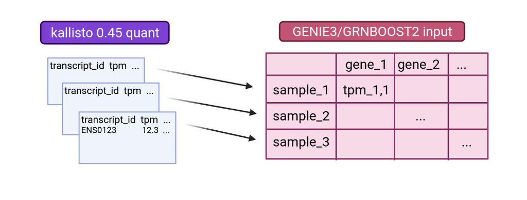

4

The code below does this and is separated in 4 functions (description in code):

1. JoinSamplesCountsMatrixes
2. Id2GeneName
3. FormatExpCountsMatrix
4. MakeExpCountsMatrix

```r
R

#################################################################################################
## Function: Join counts matrixes from several samples (rna-seq kallisto quant runs)
##           Output: Data frame. Experiments count matrix
##                  Format: Cols : target_id, sample1_counts, ..., sampleN_counts
##                  count type: tpm

JoinSamplesCountsMatrixes <- function(files, counts_col = 5){

    library(stringr)
    i = 1

    for (file in files) {
      ## Get id and tpm columns from counts file
      counts_file = as.data.frame(read.csv(file = file, header = TRUE, sep = "\t"))
      sample_name = str_extract(file, "GSM\\d*")
      colnames(counts_file)[counts_col] = sample_name # replace counts_col for name of sample

      ## Sort table by transcript id
      sort_index = match(sort(counts_file[,1]), counts_file[,1])
      counts_file = counts_file[sort_index,]
      # Note: ids are not repited

      ## Add new counts to experiment counts table
      if (i == 1){
        # first counts table
        exp_counts = counts_file[,c("target_id", sample_name)]
        i = i+1
      } else {
        # 2-n counts table
        if ( length(exp_counts$target_id[exp_counts$target_id == counts_file$target_id]) ){
          # same transcripts
          exp_counts[,sample_name] = counts_file[,sample_name]
        } else {
          # add new transcripts
          new_transcripts = setdiff(counts_file$target_id, exp_counts$target_id)
          append(exp_counts$target_id, new_transcripts, after = length(exp_counts$target_id))

          # sort exp_counts by target_id again
          sort_index = match(sort(exp_counts[,1]), exp_counts[,1])
          exp_counts = exp_counts[sort_index,]

          # add counts
          exp_counts[,sample_name] = counts_file[,sample_name]
        }
      } # else 2-n table
    } # for file

    return(exp_counts)
}


#################################################################################################
## Function: Convert transcript ids (w/ version) to gene_names with ensemblv103

Id2GeneName <- function(ensembl_ids){

    # Use biomart package from Bioconductor
    library(biomaRt)

    mart = useMart(biomart="ENSEMBL_MART_ENSEMBL",
                    dataset = "hsapiens_gene_ensembl",
                    host = "https://feb2021.archive.ensembl.org") # v 103

    # Create a query and send it to biomart server, takes 1 min
    res = getBM(attributes = c('ensembl_transcript_id_version',
                                'external_gene_name'),
                 filters = 'ensembl_transcript_id_version',
                 values = ensembl_ids,
                 mart = mart)

    # Sort results (transcript id and gene name df) by transcript_id
    sort_index = match(sort(res$ensembl_transcript_id_version),res$ensembl_transcript_id_version)
    res = res[sort_index,]
    # Note: several transcripts can correspond to the same gene

    return(res)
}


#################################################################################################
## Function: Replace target_ids for gene_names in experiment counts matrix
##          Output: Experiment counts matrix
##                  Format: df: samples (rows) x genes (columns)

FormatExpCountsMatrix <- function(exp_counts, res, transposed = T){

    library(dplyr)

    # Index of ids for which an external_gene_name was found
    index_genenames = match(res$ensembl_transcript_id_version, exp_counts$target_id)
    # Add gene names where it was found
    exp_counts[index_genenames, "external_gene_name"] = res$external_gene_name
    # Replace na's in gene_name col with ensembl_ids
    exp_counts$external_gene_name[-index_genenames] = exp_counts$target_id[-index_genenames]


    # Make new experiments counts matrix: samples (rows) x gene names (columns)
    if(transposed){
      only_counts = exp_counts %>% select_if(is.numeric)
      exp_counts_t = as.data.frame(t(as.matrix( only_counts )))
      colnames(exp_counts_t) = exp_counts$external_gene_name
    } else {
      exp_counts_t = exp_counts %>% relocate(external_gene_name, .before = target_id)
      exp_counts_t = exp_counts_t[,-2]
    }

    return(exp_counts_t)
}

#################################################################################################
## Function: Join the actions of the functions before
##            to make a single matrix joining the gene counts of several samples
##            coming from a single experiment and output that to csv

MakeExpCountsMatrix <- function(files, outfile_name = "experiment_counts.csv", transposed = T){

    # 1. Join counts matrixes from all biological replicates/ samples
    exp_counts = JoinSamplesCountsMatrixes(files)

    # 2. Get conversion of transcript ids to gene_names
    ensembl_ids = as.array(exp_counts[, "target_id"]) # transcript_ids from all samples
    id_gene_df =  Id2GeneName(ensembl_ids)

    # 3. Adjust format of experiment matrix: samples x genes
    exp_counts_t = FormatExpCountsMatrix(exp_counts = exp_counts, res = id_gene_df, transposed = transposed)

    # output experiment counts matrix
    if(transposed){
      write.table(x = exp_counts_t, file = outfile_name, sep = ",", eol = "\n", na = "NA", row.names = T, col.names = T, quote = F)
    } else {
      write.table(x = exp_counts_t, file = outfile_name, sep = ",", eol = "\n", na = "NA", row.names = F, col.names = T, quote = F)
    }
}

## Run code above only for experiment: SARS-CoV-2_infected_A549
files = c("GSM4432387/abundance.tsv", "GSM4432388/abundance.tsv", "GSM4432389/abundance.tsv",
          "GSM4462339/abundance.tsv", "GSM4462340/abundance.tsv", "GSM4462341/abundance.tsv")
MakeExpCountsMatrix(files = files, outfile_name = "SARS-CoV-2_infected_A549-counts.csv") # for grnboost2 input
MakeExpCountsMatrix(files = files, outfile_name = "SARS-CoV-2_infected_A549-counts-genie3.csv", transposed = F) # for genie3 input

quit()
y

head(exp_counts_t)[1:4]
```

Example of output matrix:

```
               ARF5    M6PR    ESRRA   FKBP4
GSM4432387 101.0470 111.607 12.25140 70.2310
GSM4432388 108.9660 100.983 15.54640 77.4378
GSM4432389 122.5220 114.189 22.56570 84.2131
GSM4462339  66.0636 109.169  9.37089 39.4358
GSM4462340  87.2772 109.837 11.08310 33.8674
GSM4462341  78.9091 100.710 10.19030 31.6239
```

To make the count matrixes for all experiments:

```r
cd .. # in bash

## Run code above for all experiments in COVID19/Data/counts2/
for(experiment_dir in dir( path = ".",include.dirs = T)){

  # skip if SARS-CoV-2_infected_A549 or jobs dirs
  if(experiment_dir == "jobs" || experiment_dir=="SARS-CoV-2_infected_A549") next

  # list all counts files in files
  files = c()
  for(sample_dir in dir(experiment_dir)){
    files = append(files, paste(sample_dir, "abundance.tsv", sep = "/"), after = length(files))
  }

  # run code
  MakeExpCountsMatrix(files = files, outfile_name = paste(experiment_dir,"counts.csv",sep = "-") )
}
```

### **Pyscenic Pipeline**

Ananconda environment:

```bash
module load anaconda3/4.2.0
source activate scanpy
```

#### **Infer modules based on coexpression:**

The `GENIE3` program for this step was initially done for bulk RNA-seq data, so it might be convenient to use it instead of `grnboost2`, which is now standard in the pipeline but that was redesigned (inspired in `GENIE3` algorithm) for scRNA-seq, which makes it more efficient since this type of data can be much bigger (thousand of cells vs few samples).

To test both, I will run them with the same seed `777` and compare the output tf-target interaction file `adj.tsv`.

cwd = `/mnt/Citosina/amedina/mpadilla/COVID19/Data/counts2/SARS-CoV-2_infected_A549`

**GRNBOOST2**

Running time: 1hr 17 min

```bash
arboreto_with_multiprocessing.py \
./SARS-CoV-2_infected_A549-counts.csv \
/mnt/Citosina/amedina/mpadilla/COVID19/pyscenic/demo/resources/hs_hgnc_tfs.txt \
--method grnboost2 \
--output adj-gb2.tsv \
--num_workers 20 \
--seed 777
```

**GENIE3**

Running time: (a lot)

Note: although genie3 input is genes(rows) x samples(cols), when running it with arboreto it should be transposed

```bash
arboreto_with_multiprocessing.py \
./SARS-CoV-2_infected_A549-counts.csv \
/mnt/Citosina/amedina/mpadilla/COVID19/pyscenic/demo/resources/hs_hgnc_tfs.txt \
--method genie3 \
--output adj-g3.tsv \
--num_workers 20 \
--seed 777
```

##### **Compare adjencies/output files**

```bash
{ wc adj-gb2.tsv & wc adj-g3.tsv; }
diff -s adj-gb2.tsv adj-g3.tsv ## check if files are identical
sort adj-gb2.tsv > adj-gb2-sort.tsv
sort adj-g3.tsv > adj-g3-sort.tsv
diff -s adj-gb2-sort.tsv adj-g3-sort.tsv ## check if files are identical
cut -f1-2 adj-gb2-sort.tsv > adj-gb2-sort-nimp.tsv
cut -f1-2 adj-g3-sort.tsv > adj-g3-sort-nimp.tsv
diff -s adj-gb2-sort-nimp.tsv adj-g3-sort-nimp.tsv ## check if files are identical
```

[output not shown]

#### **Refine modules into regulons**

Running time: 1 hr 3 min

```bash
pyscenic ctx \
./adj-gb2.tsv \
/mnt/Citosina/amedina/mpadilla/COVID19/pyscenic/demo/resources/hg38__refseq-r80__10kb_up_and_down_tss.mc9nr.feather \
--annotations_fname /mnt/Citosina/amedina/mpadilla/COVID19/pyscenic/demo/resources/motifs-v9-nr.hgnc-m0.001-o0.0.tbl \
--expression_mtx_fname ./SARS-CoV-2_infected_A549-counts.csv \
--mode "dask_multiprocessing" \
--output reg-gb2.csv \
--num_workers 20 \
--mask_dropouts
```

#### **Cellular –> Sample enrichment** (1.7 min)

Again a seed `777` was set for reproducibility.

```bash
pyscenic aucell \
./SARS-CoV-2_infected_A549-counts.csv \
reg-gb2.csv \
--output SARS-CoV-2_infected_A549-gb2-pyscenic.loom \
--num_workers 20 \
--seed 777
```

**Test notes:**

- Seeds will not be used in real runs (not tests)
- GRNBOOST2 is much faster than GENIE3 even with few samples, so it is convenient to use GRNBOOST2 when running multiruns.
- we can also use Sushmita’s Roy tool for network inference intead of grnboost2
- The set of tfs taken from pyscenic’s tutorial [1] has 1839, including zinc fingers
- We can change the list of TFs, as well as the ranking databases by creating a cisTarget db as described [here](https://pyscenic.readthedocs.io/en/latest/faq.html#can-i-create-my-own-ranking-databases) and further on [here](https://github.com/aertslab/create_cisTarget_databases) .
- We can input the modules from coexpression to [iRegulon](http://iregulon.aertslab.org/) to view them in Cytoscape as described [here](http://htmlpreview.github.io/?https://github.com/aertslab/SCENICprotocol/blob/master/notebooks/PBMC10k_downstream-analysis.html)
- pyscenic by default discards negatively coexpressed interactions, but we can add them with option `-a, --all_modules` in the refining step `pyscenic ctx`, in despite that authors have reported that these modules make no sense.
- pyscenic does not capture dynamic changes within grns, i think a Sushmita Roys tools does that

```bash
umask 2
mkdir pyscenic-test-out
mv adj* reg* SARS-CoV-2_infected_A549-gb2-pyscenic.loom pyscenic-out/
```

### **Visualization**

#### **Nonlinear projection and clustering** (variable time)

```python
import loompy as lp
import umap #from MulticoreTSNE
import MulticoreTSNE as TSNE
import pandas as pd
lf = lp.connect("PBMC10k_SCENIC.loom", mode='r+', validate=False)
auc_mtx = pd.DataFrame(lf.ca.RegulonsAUC, index=lf.ca.CellID)
lf.close()
# UMAP
runUmap = umap.UMAP(n_neighbors=10, min_dist=0.4, metric='correlation').fit_transform
dr_umap = runUmap(auc_mtx)
# tSNE
tsne = TSNE(n_jobs=20)
dr_tsne = tsne.fit_transform(auc_mtx)
```

### **References**

[1] Van de Sande, B., Flerin, C., Davie, K., De Waegeneer, M., Hulselmans, G., Aibar, S., … & Aerts, S. (2020). A scalable SCENIC workflow for single-cell gene regulatory network analysis. Nature Protocols, 15(7), 2247-2276.

[2] Blanco-Melo, D., Nilsson-Payant, B. E., Liu, W. C., Uhl, S., Hoagland, D., Møller, R., … & Albrecht, R. A. (2020). Imbalanced host response to SARS-CoV-2 drives development of COVID-19. Cell, 181(5), 1036-1045.

Images made with [bioRender](https://biorender.com/)

https://github.com/aertslab/pySCENIC/issues/136

**Programs**

- r/4.0.2
  - dyplr
  - stringr
- genie3
- grnboost2
- pyscenic
- anaconda3/4.2.0
- scanpy anaconda env